# Lösung_Übung_06,2

# Aufgabe 2

Daten einlesen:

```r
df <- data.frame(Geschlecht = factor(c("m", "w", "w", "w", "m", "w", "m", "m", "w", "m")),
                 Lerndauer = c(3.7, 5.4, 2.3, 1.8, 2.6,  8.4, 1.5, 5.8, 4.5, 2.1))

knitr::kable(df, align = "ll")
```

| Geschlecht | Lerndauer |
| --- | --- |
| m | 3.7 |
| w | 5.4 |
| w | 2.3 |
| w | 1.8 |
| m | 2.6 |
| w | 8.4 |
| m | 1.5 |
| m | 5.8 |
| w | 4.5 |
| m | 2.1 |

## Aufgabe 2a)

Das Merkmal Geschlecht ist nominalskaliert, da es keine (sinnvolle) Ordnnungsrelation für das Geschlecht gibt. Das Geschlecht ist außerdem ein diskretes Merkmal, weil es nur endlich viele Merkmalsausprägungen gibt.

Das Merkmal Lerndauer ist verhältnisskaliert, da es eine eine natürliche Ordnung gibt, sich Abstände und Verhältnisse sinnvoll interpretieren lassen und es eine natürliche 0 gibt (gar nicht gelernt). Es ist nicht Absolutskaliert, da die Einheit in der die Lerndauer gemessen wird willkürlich ist. Es kann auch genauso gut in Minuten gemessen werden. Die Lerndauer ist ein stetiges Merkmal, weil die Lerndauer beliebig präzise angegeben werden kann. Alternativ: Die Lerndauer ist ein quasi-stetiges Merkmal, weil die Lerndauer mit einer Nachkommastelle so viele Ausprägungen hat, dass es Sinn macht, das Merkmal wie ein stetiges Merkmal zu behandeln.

## Aufgabe 2b)

**Zeichnen Sie die empirische kumulative Verteilungsfunktion von der Lerndauer.**

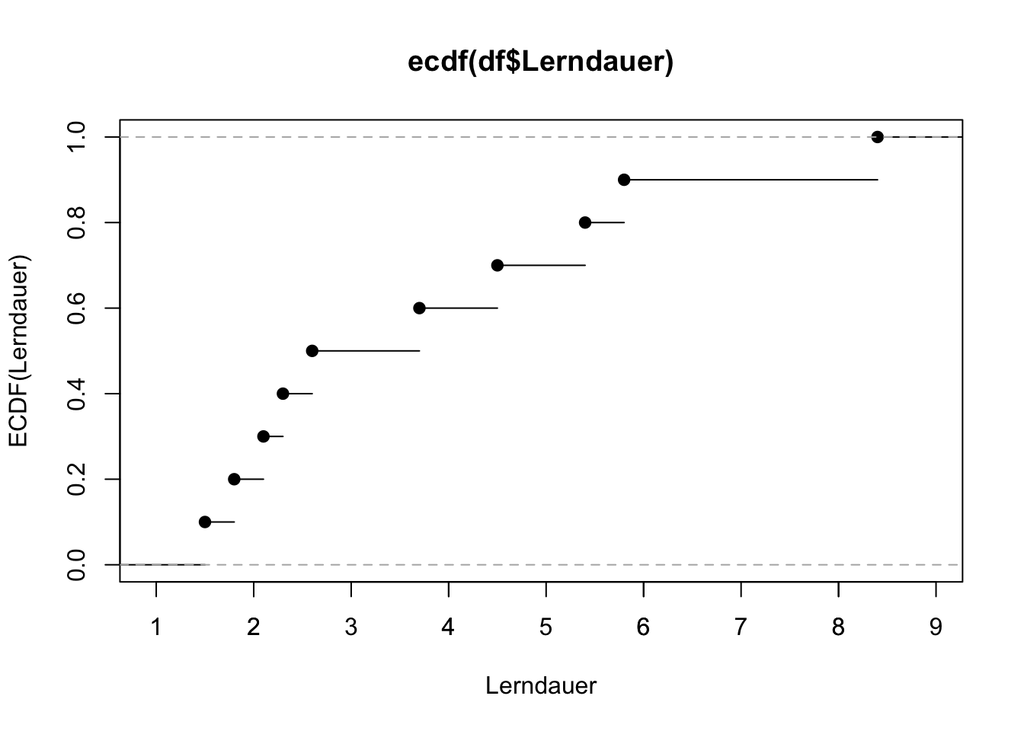

```r
plot(ecdf(df$Lerndauer), ylab = "ECDF(Lerndauer)", xlab = "Lerndauer")
axis(side=1, at=1:9)
```

## Aufgabe 2c)

**Wie viel lernten die 20% der Studierenden, welche am wenigsten Lernzeit investiert haben, höchstens?**

Möglichkeit 1: Wir ordnen die Lerndauer an: 1.5, 1.8, 2.1, 2.3, 2.6, 3.7, 4.5, 5.4, 5.8, 8.4  
Davon betrachten wir die unteren 20% der Werte: 1.5, 1.8  
Und von denen nehmen wir den höchsten Wert: 1.8

Möglichkeit 2: Wir benutzen die `quantile` Funktion mit `type = 1`. Diese berechnet $Q(p) := \inf\{x\mid p \leq F(x)\}$.

```r
quantile(df$Lerndauer, 0.2, type = 1)
```

```
## 20%
## 1.8
```

## Aufgabe 2d)

Wir unterscheiden im folgenden nur noch zwischen den beiden Klassen “kurz gelernt” für eine Lerndauer $\leq$ 4 und “lange gelernt” für eine Lerndauer > 4 Stunden.

**Erstellen Sie eine entsprechende Kreuztabelle für das klassierte Merkmal “Lerdauer (kurs/lang)” und das Geschlecht. Wie groß ist der Anteil unter den Frauen, die nur “kurz gelernt” haben?**

```r
# Klassieren von Lerndauer
df$Lerndauer <- factor(ifelse(df$Lerndauer <= 4, "kurz gelernt", "lang gelernt"))

# Erzeuge eine Kontingenztabelle (contingency table)
cont <- table(df)
addmargins(cont)
```

```
##           Lerndauer
## Geschlecht kurz gelernt lang gelernt Sum
##        m              4            1   5
##        w              2            3   5
##        Sum            6            4  10
```

```r
# relative Häufigkeiten
prop_cont <- prop.table(cont)
addmargins(prop_cont)
```

```
##           Lerndauer
## Geschlecht kurz gelernt lang gelernt Sum
##        m            0.4          0.1 0.5
##        w            0.2          0.3 0.5
##        Sum          0.6          0.4 1.0
```

```r
# relative Häufigkeiten bedingt auf Geschlecht
prop_cont_Geschlecht <- prop.table(cont, margin = 1)
addmargins(prop_cont_Geschlecht, margin = 2)
```

```
##           Lerndauer
## Geschlecht kurz gelernt lang gelernt Sum
##          m          0.8          0.2 1.0
##          w          0.4          0.6 1.0
```

```r
# relative Häufigkeiten bedingt auf Lerndauer
prop_cont_Lerndauer <- prop.table(cont, margin = 2)
addmargins(prop_cont_Lerndauer, margin = 1)
```

```
##           Lerndauer
## Geschlecht kurz gelernt lang gelernt
##        m      0.6666667    0.2500000
##        w      0.3333333    0.7500000
##        Sum    1.0000000    1.0000000
```

Der Anteil an Frauen die nur “kurz gelernt” haben ist also 0.4.

## Aufgabe 2e)

Sie wollen grafisch darstellen ob bzw. wie stark sich diese klassierte Lerndauer zwischen den Geschlechtern unterscheiden. Zeichnen Sie einen geeigneten Mosaikplot der Daten.

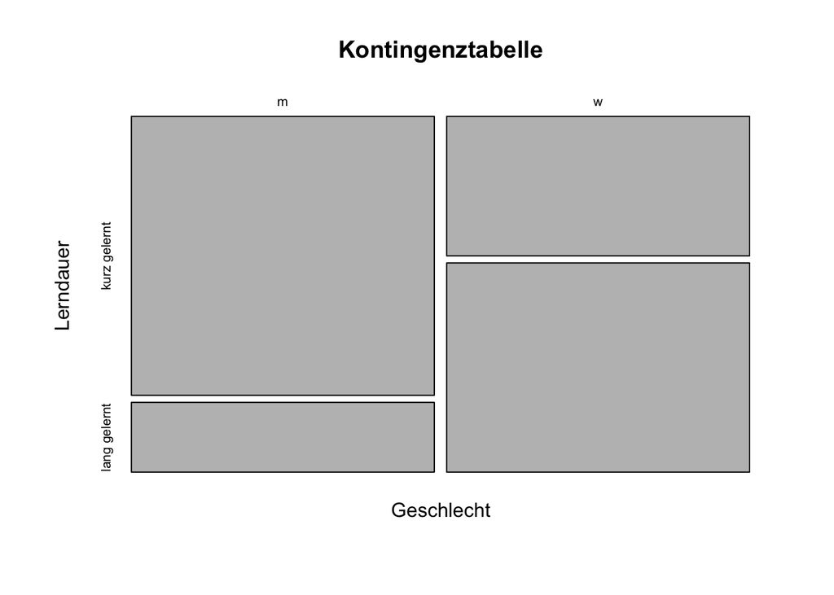

```r
mosaicplot(cont, main = "Kontingenztabelle")
```